# Week7-Data_Visualisation-solution

## Data Visualisation

You know what they say... a picture is worth a thousand words! In this practical we will be trying to get some insights about a dataset by looking at various plots. Note that by no means is the below an extensive or exhaustive list of all of the different ways you can visualise data... :) We are only going to be looking at the most common types of visualisation; this is going to be useful for Coursework 1 too.

Here is a list of [books](https://www.tableau.com/en-gb/learn/articles/books-about-data-visualization) on Data Visualisation if you are interested in the topic more (fun fact: the list is compiled by Tableau, a big Data Visualisation company!).

We will be using Pandas again to load data and `matplotlib` and mostly `seaborn` to create plots. Whenever in doubt always refer to the manual for Matplotlib [here](https://matplotlib.org) and seaborn [here](https://seaborn.pydata.org).

The dataset we will use today is another "classic" Machine Learning called "Red Wine Quality" (it's the same we used to test the k-nn implementation). You can find details about it [here](https://archive.ics.uci.edu/ml/datasets/wine+quality).

## Load Dataset

Let's load the dataset first using Pandas. Since the data is in .csv format we will have to use `pd.read_csv()`.

Just by looking at the `DataFrame` table we can tell that the dataset consists of numerical values. Although we are not going to perform any predictions in this Practical, we can assume that label is the last column "quality".

```python
!pip install pandas numpy seaborn matplotlib
```

```python
import pandas as pd

data = pd.read_csv('red-wine.csv', sep=';')
data
```

|  | fixed acidity | volatile acidity | citric acid | residual sugar | chlorides | free sulfur dioxide | total sulfur dioxide | density | pH | sulphates | alcohol | quality |
| --- | --- | --- | --- | --- | --- | --- | --- | --- | --- | --- | --- | --- |
| 0 | 7.4 | 0.700 | 0.00 | 1.9 | 0.076 | 11.0 | 34.0 | 0.99780 | 3.51 | 0.56 | 9.4 | 5 |
| 1 | 7.8 | 0.880 | 0.00 | 2.6 | 0.098 | 25.0 | 67.0 | 0.99680 | 3.20 | 0.68 | 9.8 | 5 |
| 2 | 7.8 | 0.760 | 0.04 | 2.3 | 0.092 | 15.0 | 54.0 | 0.99700 | 3.26 | 0.65 | 9.8 | 5 |
| 3 | 11.2 | 0.280 | 0.56 | 1.9 | 0.075 | 17.0 | 60.0 | 0.99800 | 3.16 | 0.58 | 9.8 | 6 |
| 4 | 7.4 | 0.700 | 0.00 | 1.9 | 0.076 | 11.0 | 34.0 | 0.99780 | 3.51 | 0.56 | 9.4 | 5 |
| ... | ... | ... | ... | ... | ... | ... | ... | ... | ... | ... | ... | ... |
| 1594 | 6.2 | 0.600 | 0.08 | 2.0 | 0.090 | 32.0 | 44.0 | 0.99490 | 3.45 | 0.58 | 10.5 | 5 |
| 1595 | 5.9 | 0.550 | 0.10 | 2.2 | 0.062 | 39.0 | 51.0 | 0.99512 | 3.52 | 0.76 | 11.2 | 6 |
| 1596 | 6.3 | 0.510 | 0.13 | 2.3 | 0.076 | 29.0 | 40.0 | 0.99574 | 3.42 | 0.75 | 11.0 | 6 |
| 1597 | 5.9 | 0.645 | 0.12 | 2.0 | 0.075 | 32.0 | 44.0 | 0.99547 | 3.57 | 0.71 | 10.2 | 5 |
| 1598 | 6.0 | 0.310 | 0.47 | 3.6 | 0.067 | 18.0 | 42.0 | 0.99549 | 3.39 | 0.66 | 11.0 | 6 |

1599 rows × 12 columns

## Exercise 1 - Histograms

The most basic type of visualisation we can perform on our data is to look at the frequencies of values for each feature. Depending on the type of each feature we can use a different plotting mechanism. Let's start with numerical features (since this is what we mostly have here); the tool in our arsenal is a **histogram** (`sns.distplot(data, bins=num_of_bins)`).

The idea is that the x-axis corresponds to the various feature values and the y-axis corresponds to the frequency. Since numerical values can take an unbounded number of values, it's a good idea to group values into bins: this way we can decide to *zoom-in* or *zoom-out* by using more or fewer number of bins, respectively.

Let's try to plot a few histograms with different parameters for the `fixed acidity` feature:

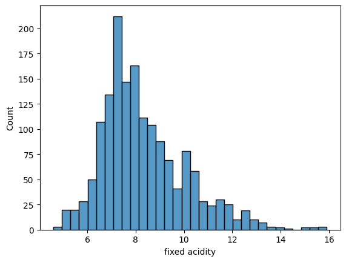

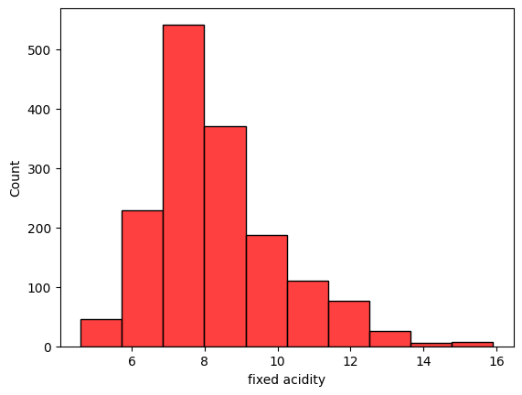

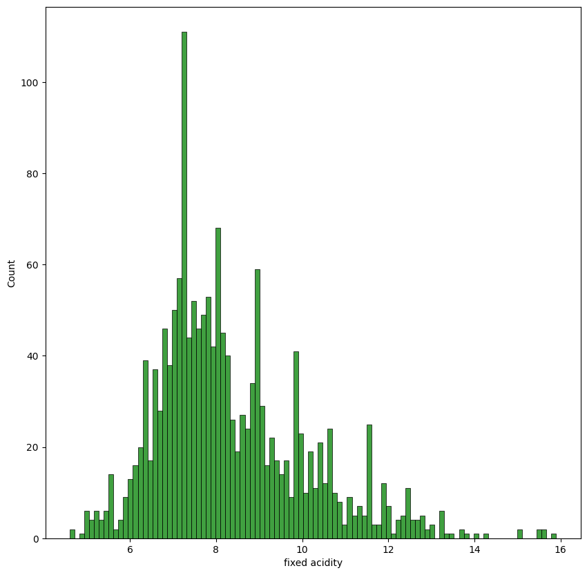

```python
import numpy as np
import pandas as pd
import seaborn as sns
import matplotlib.pyplot as plt

%matplotlib inline

# if we don't specify a value for the parameter 'bins', it gets determined automatically
sns.histplot(data['fixed acidity'])
# `plt.show()` command tells the intepreter to show the plot immediately.
# Try commenting it out and see what happens! Answer: seaborn will overlap the two plots...sometimes this can be handy!
plt.show()

# let's try with a different bin size
sns.histplot(data['fixed acidity'], bins=10, color='red')
plt.show()

# let's try with a bigger bin size... this time let's create a bigger plot to be able to see more detail
fig=plt.figure(figsize=(10,10))
sns.histplot(data['fixed acidity'], bins=100, color='green')
plt.show()
```

Now let's try plotting the frequency plot for a categorical feature (the `quality` feature). We will use bar-plots for this case using `sns.countplot(data, y=feature_name)` for an horizontal bar-plot or `sns.countplot(data, x=feature_name)` for vertical.

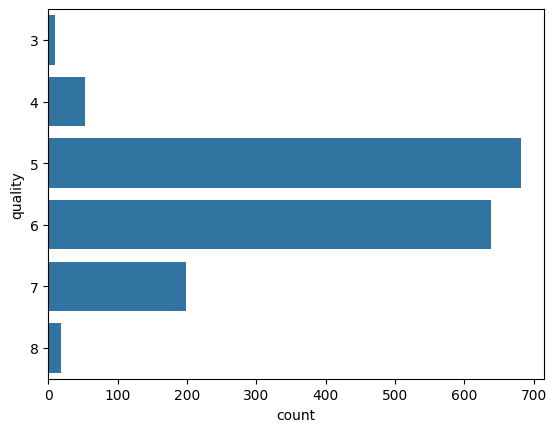

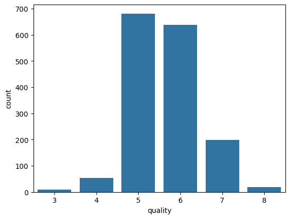

```python
sns.countplot(data=data, y='quality')
plt.show()

# or vertical if you prefer it better... notice the difference
sns.countplot(data=data, x='quality')
plt.show()
```

Now your turn! Plot the histograms for `citric acid` and `chlorides`. Just by looking at them, what can you tell about the distribution of their values? (Hint: Try plotting them together in one plot instead of two separate histograms).

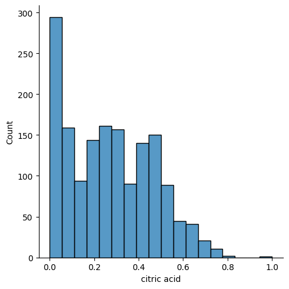

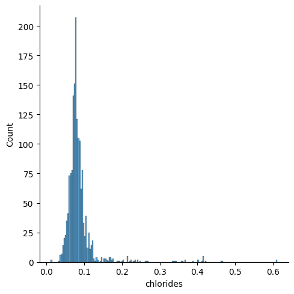

```python
#TODO: Implement
sns.displot(data['citric acid'])
sns.displot(data['chlorides'])
```

## Exercise 2 - Visualising Correlations

Sometimes we want to know whether pairs of features correlate with each other. We are going to explore two different ways:

### Heatmap

Heatmaps are a type of plot where values are depicted by color. They are particularly useful when we want to take a *snapshot* of the features and understand them in one go.

Let's draw the heatmap of the correlation matrix of features in our dataset using `sns.heatmap()` and `data.corr()`.

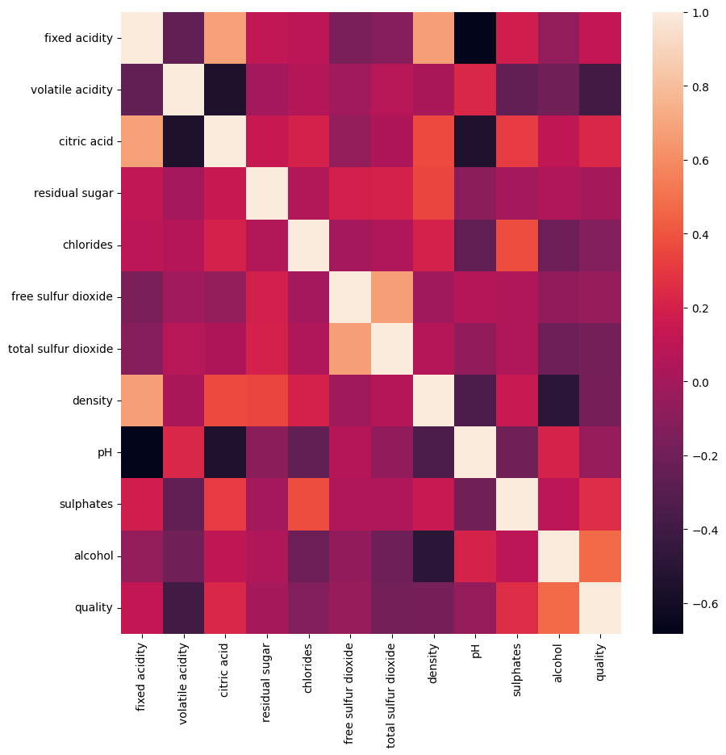

```python
fig=plt.figure(figsize=(10,10))
sns.heatmap(data.corr(),color='blue')
plt.show()
```

### Scatter Plot + Linear Regression Fit

Now let's zoom-in to just a pair of features, draw a scatter plot of their values (x-axis=values of the 1st feature, y-axis=values of the 2nd feature) and fit a linear regression model as well... nice!

According to the heatmap above it seems like `citric acid` and `fixed acidity` seem to be related. We will use `seaborn.regplot(x=feature_one, y=feature_two, data)` to look closer:

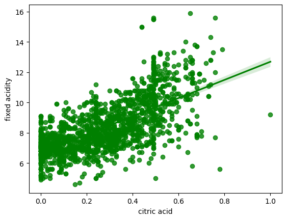

```python
sns.regplot(x='citric acid', y='fixed acidity', data=data, color='green')
plt.show()
```

They seem to be fairly correlated (positively).

Your turn! Find another pair from the heatmap above that seems to have a negative correlation.

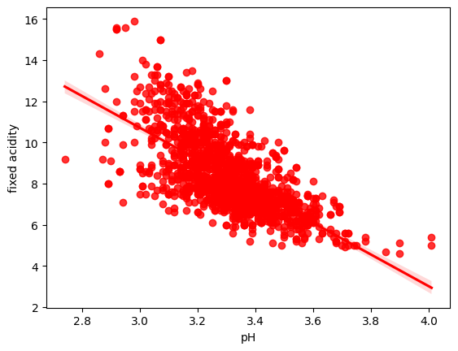

```python
#TODO: Implement
sns.regplot(x='pH', y='fixed acidity', data=data, color='red')
plt.show()
```

## Exercise 3 - (Simple) Plots

You might be asking...what if I just want to plot the values of a feature for every example, i.e., x-axis=example and y=feature_value? Matplotlib comes to the rescue!

In the following we will plot the values of the feature `pH` for every example using the basic `plt.plot()` function:

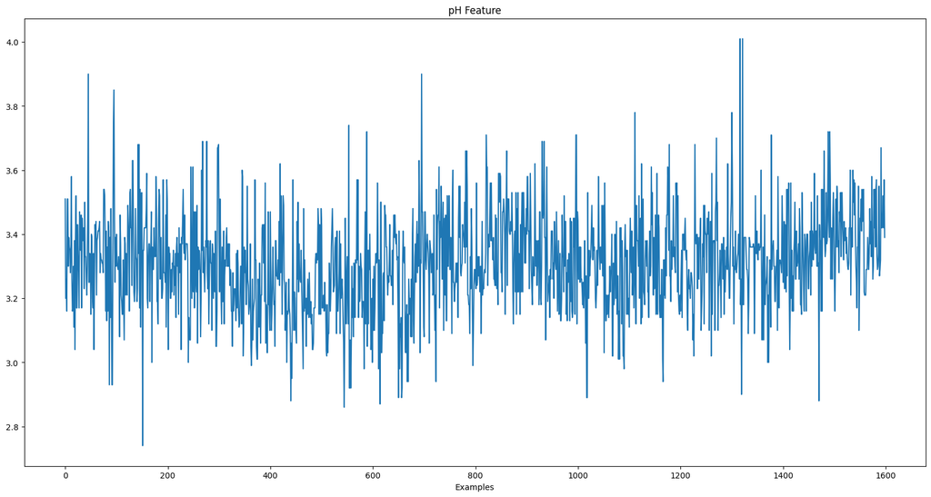

```python
fig=plt.figure(figsize=(20,10))
plt.xlabel('Examples')
plt.title('pH Feature')
plt.plot(data[['pH']])
```

So `plt.plot()` is the most generic way that doesn't make any assumptions to the input: it can be anything from a simple list, to a numpy area or a Pandas DataFrame. However, it can be a bit clanky (e.g., trying to put a legend properly). In case you have your data loaded in a Pandas DataFrame (as in this case) you can also use the `data.plot()` function, i.e., execute it directly on the DataFrame:

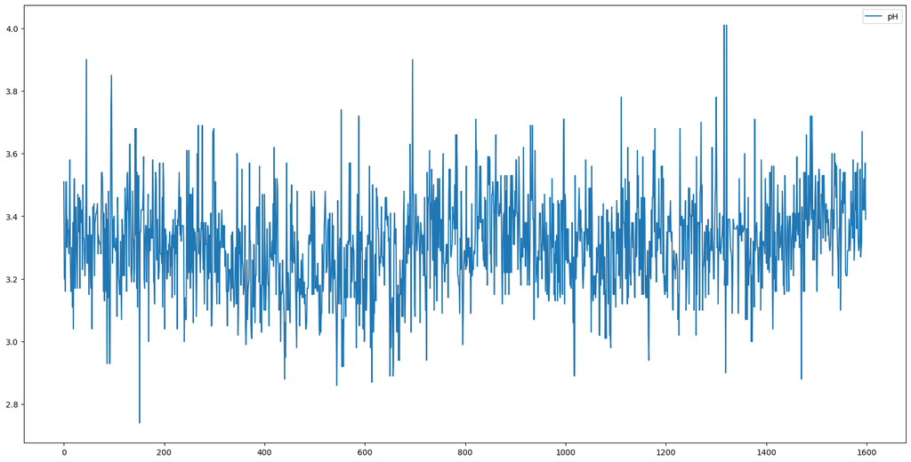

```python
data.plot(y='pH', figsize=(20,10))
```

Now your turn! Draw 3 different features in the same plot. Try doing it both with `plt.plot()` and `data.plot()`.

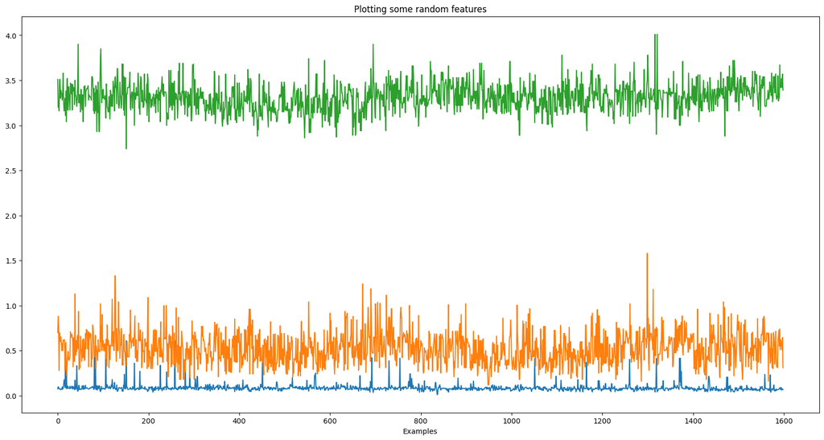

```python
fig=plt.figure(figsize=(20,10))
plt.xlabel('Examples')
plt.title('Plotting some random features')
plt.plot(data[['chlorides', 'volatile acidity', 'pH']])
```

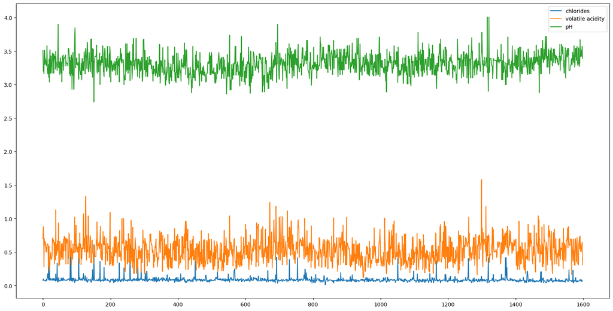

```python
data.plot(y=['chlorides', 'volatile acidity', 'pH'], figsize=(20,10))
```